# Week 3: ggplot

Justin Baumann

13 August, 2020

# **Additional Tutorials and Resources for graphs in ggplot**

[Basics of ggplot](http://www.cookbook-r.com/graphs)

[Colors with ggsci](https://cran.r-project.org/web/packages/ggsci/vignettes/ggsci.html)

[TidyTuesday](https://github.com/rfordatascience/tidytuesday): Data for playing w/ ggplot features. Follow #TidyTuesday on twitter for inspo

[Many plots, 1 page w/ Patchwork](https://github.com/thomasp85/patchwork)

[TRY some ggplot functions on your own](https://rstudio.cloud/learn/primers/3)

The best way to learn is to GOOGLE IT and try stuff

# **LEARNING OBJECTIVES**

1.) Apply basic plotting functions to new data  
2.) Add color, themes, and other aesthetics  
3.) Learn how to panel plots w/ patchwork  
4.) IF TIME PERMITS: use dplyr data manipulation (%>%) & ggplot together! –> aka, try a tidytuesday challenge

# **Step 1: Load any packages we may need**

```r
knitr::opts_chunk$set(echo = TRUE)
library(tidyverse)
library(vegan)
```

```r
library(ggsci) #this package allows us to EASILY add good color schemes to plot
library(patchwork) #this package is used to panel many plots onto 1 page
```

# **Step 2: a review of basic ggplot + some new details!**

#### ggplot2 is a data visualization package within R. It is separate from the base R plot() function and (with few exceptions) is the best option for making graphs and data visualizations in R. It is pretty easy to learn, has great tutorials and documentation (cookbook-r.com/graphs is incredibly useful), and tends to result in better looking graphs.

## Anatomy of a (simple) ggplot

#### Let’s work with mtcars again. We will make a scatterplot, the simplest of options in ggplot.

### Scatterplot

#### Every ggplot starts with a call of the main function “ggplot()”. If we want, we can define the data source and aestethics (aes) within this function.

#### Next, we want to call the geometry function (what shapes do we want in our plot?). Here, we choose ‘geom_point’ to make points. Note that we can also define the data source and aes inside this function INSTEAD of the ‘ggplot()’ function. WHY might this be useful?

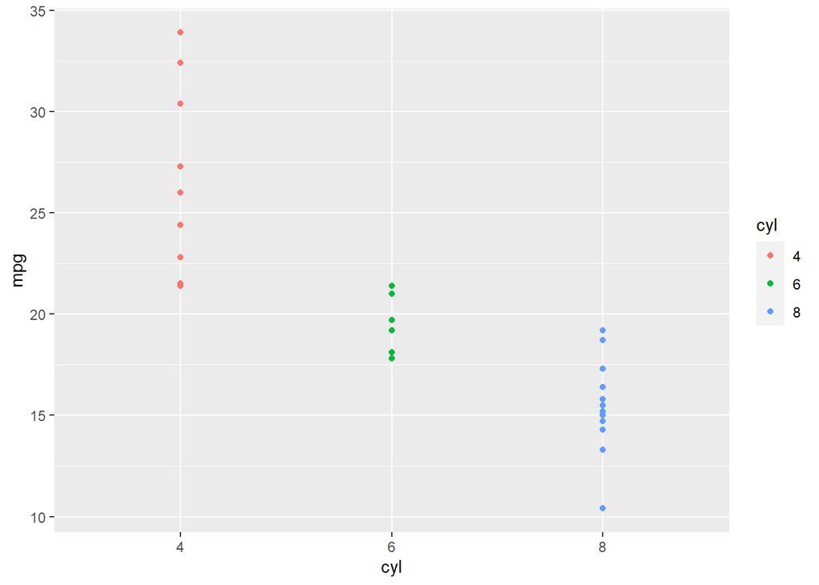

```r
mtcars$cyl=as.factor(mtcars$cyl)

ggplot(data=mtcars, aes(x=cyl, y=mpg, color=cyl))+
  geom_point()
```

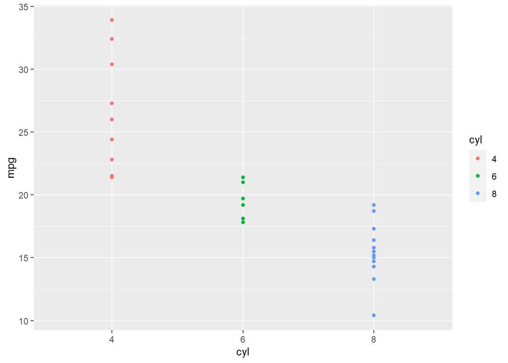

```r
ggplot()+
  geom_point(data=mtcars, aes(x=cyl, y=mpg, color=cyl))
```

### We just made 2 graphs that look exactly the same using slightly different code. Hopefully you can see that ggplot() is very flexible.

## Changing Shape, Size, and Color of points

### Shape of Points

#### ggplot gives us options to change point shape using the aesethic option ‘shape’

#### WE can either change shape based on a characterstic of the data (‘cyl’, for example), make all the shapes the same, or manually control shape

#### Below is a table of shape options

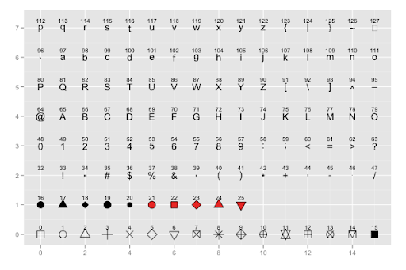

### Conditional Shape Change

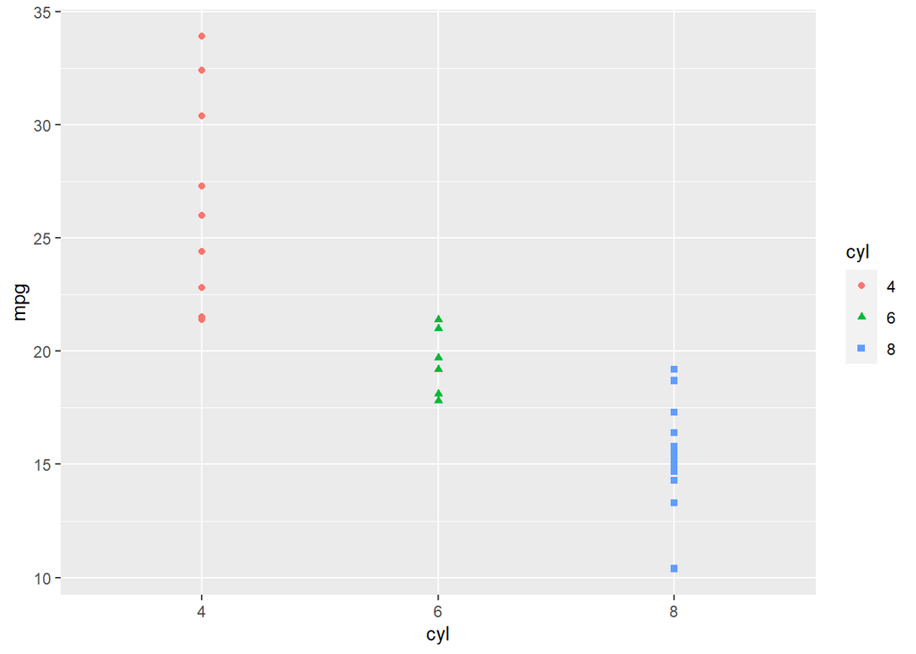

```r
ggplot(data=mtcars, aes(x=cyl, y=mpg, color=cyl, shape=cyl))+ #note that we added 'shape=' to our aes.
  geom_point()
```

### Change all shapes to triangles (shape number 17 in the image above)

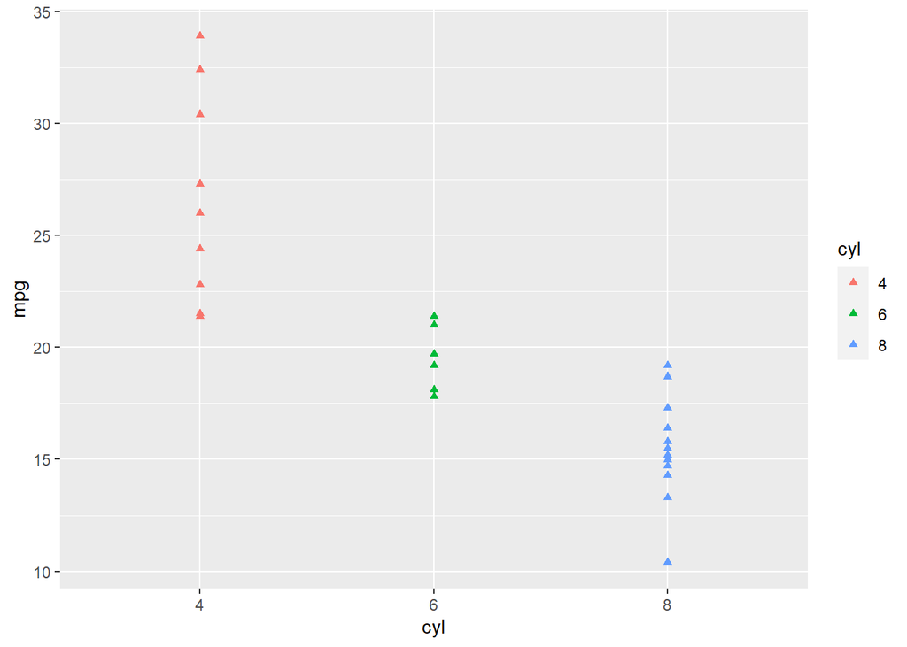

```r
ggplot(data=mtcars, aes(x=cyl, y=mpg, color=cyl))+
  geom_point(shape=17) #Here 'shape=' is inside the settings for geom_point. Note that it is outside the aes() function, as that applied aesethics conditionally)
```

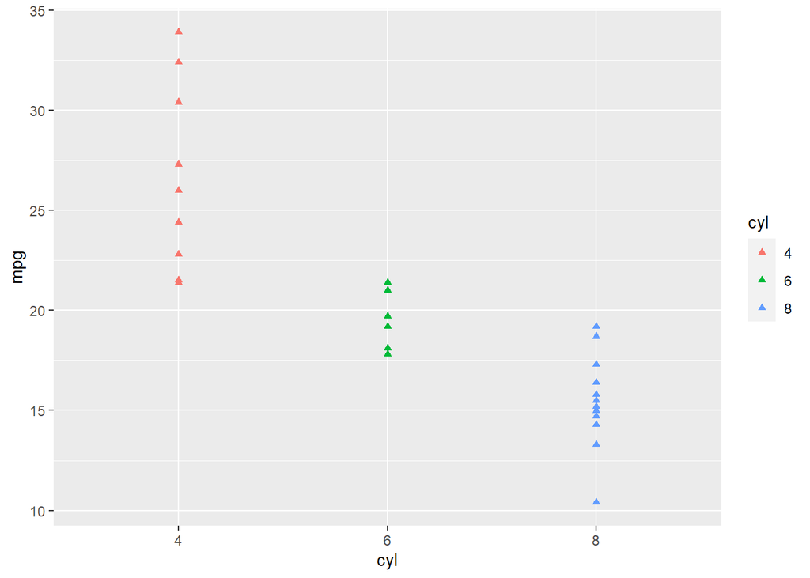

```r
#example 2, same w/ different syntax
ggplot()+
  geom_point(data=mtcars, aes(x=cyl, y=mpg, color=cyl), shape=17)
```

### Manual shape changes

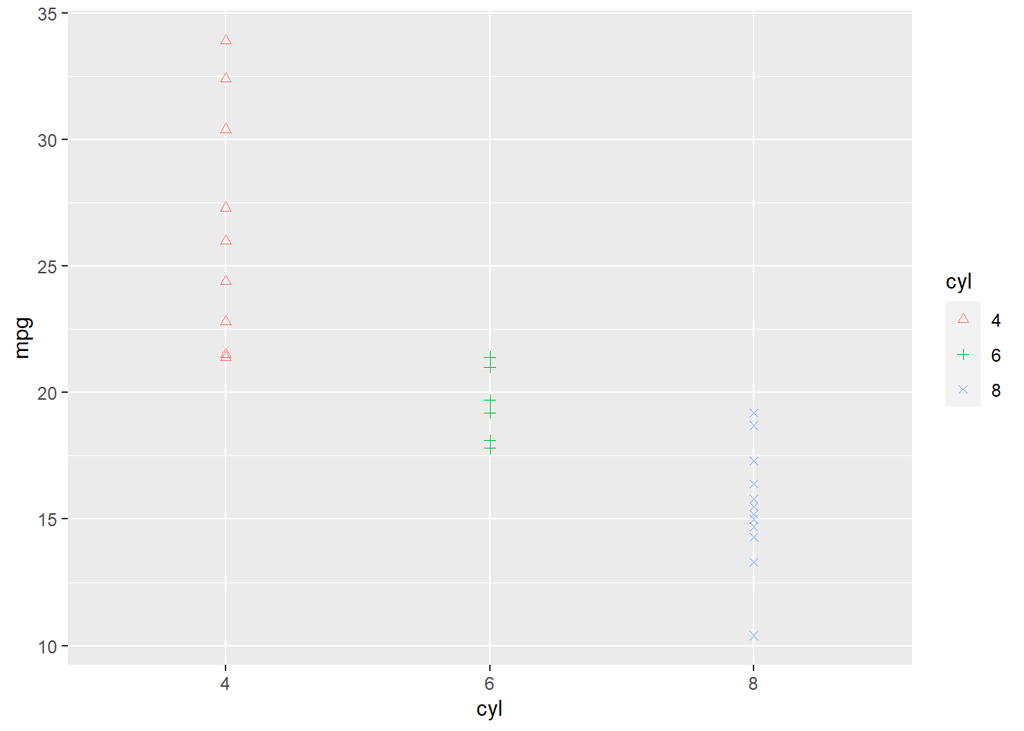

```r
ggplot()+
  geom_point(data=mtcars, aes(x=cyl, y=mpg, color=cyl, shape=cyl))+
  scale_shape_manual(values=c(2,3,4)) #scale_shape_manual allows us to choose shapes for each group (cyl in this case). c stands for concatenate, as we've seen before
```

## Changing Size of points

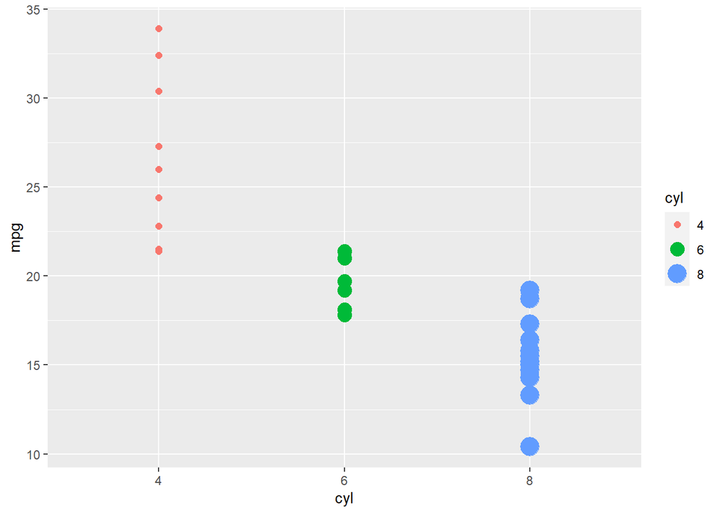

```r
ggplot(data=mtcars, aes(x=cyl, y=mpg, color=cyl, size=cyl))+ #note that we added 'size=' to our aes.
  geom_point()
```

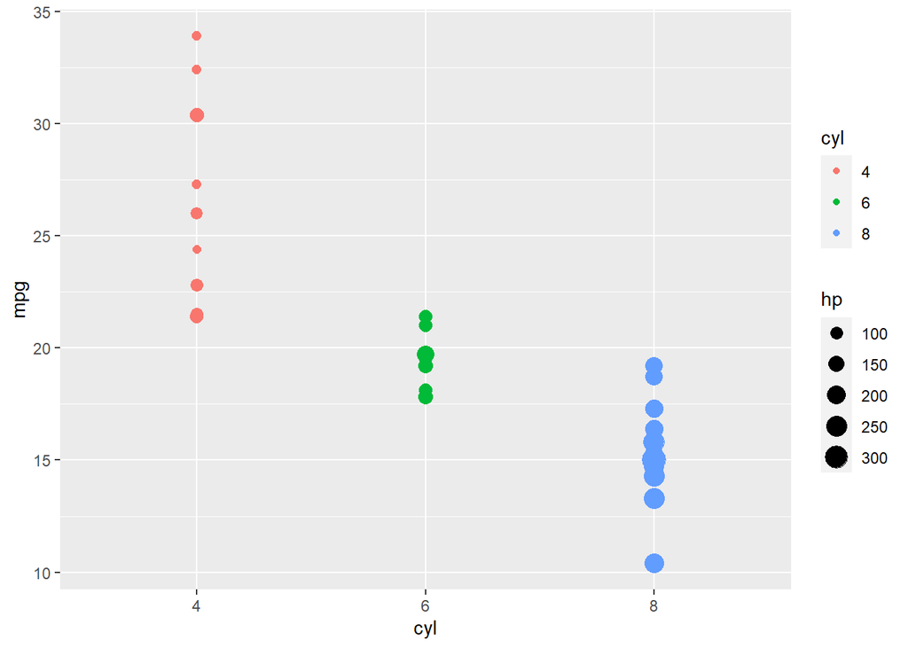

```r
#note the warning message that using size for a discrete variable is not best practice.
#Instead, let's use the size to five us an idea of hp (a 3rd variable)

ggplot(data=mtcars, aes(x=cyl, y=mpg, color=cyl, size=hp))+ #note that we added 'size=' to our aes.
  geom_point()
```

### Change size of all points (all points must be same size)

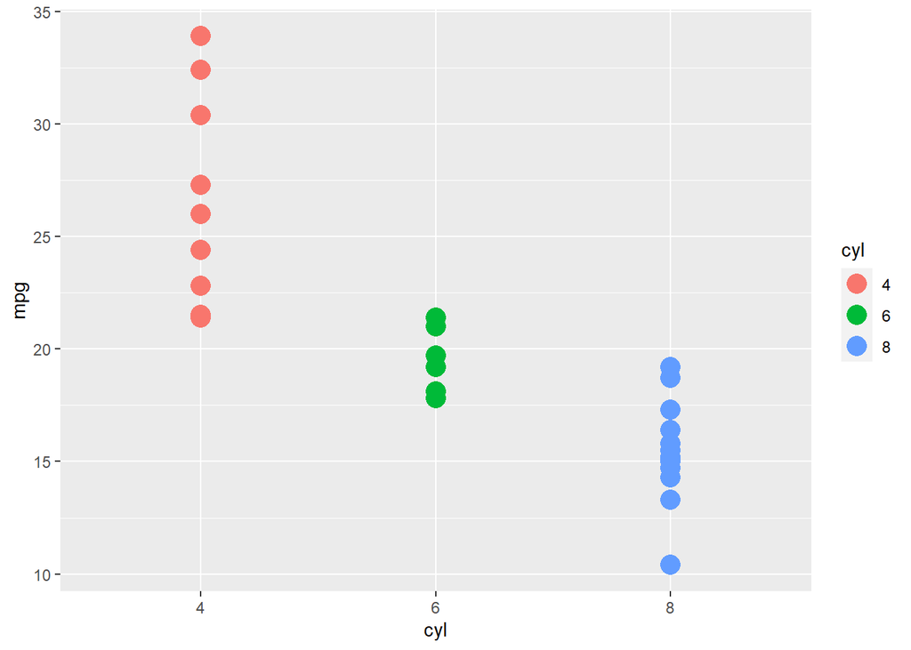

```r
ggplot(data=mtcars, aes(x=cyl, y=mpg, color=cyl))+
  geom_point(size=5) #as w/ shape, point needs to be outside the aes() here.
```

## Changing colors (the basics)

### Conditional color change

#### We are already doing this, with color= inside our aes() call

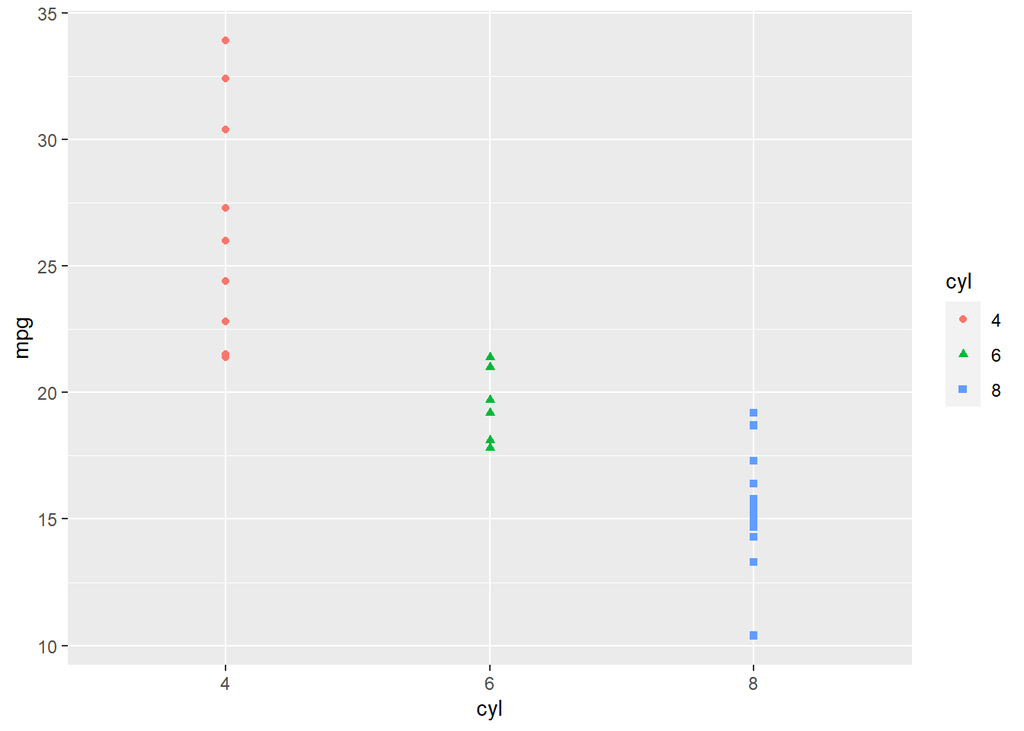

```r
ggplot(data=mtcars, aes(x=cyl, y=mpg, color=cyl, shape=cyl))+ #NOTE: we can use color= or fill = or both depending on our needs
  geom_point()
```

### Manual color change

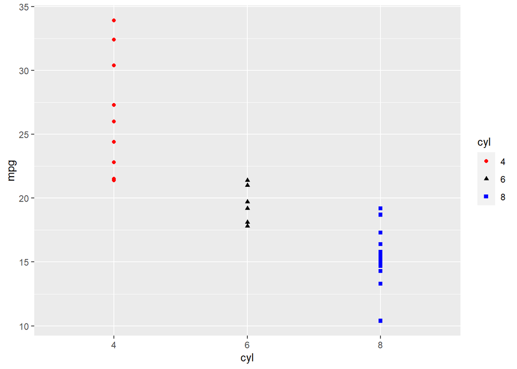

```r
ggplot(data=mtcars, aes(x=cyl, y=mpg, shape=cyl))+
  geom_point(aes(color=cyl))+
  scale_color_manual(values=c('red', 'black', 'blue')) #we can use scale_color_manual to change colors. The order is the same as the order in the legend! NOTE: we can also 'scale_fill_manual'
```

### ggplot color options:

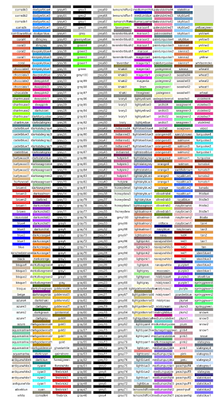

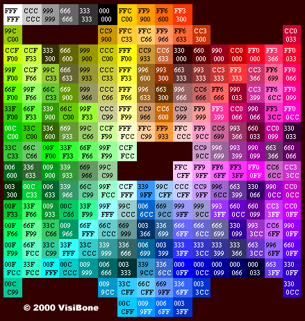

### another color option: Make your own color palette

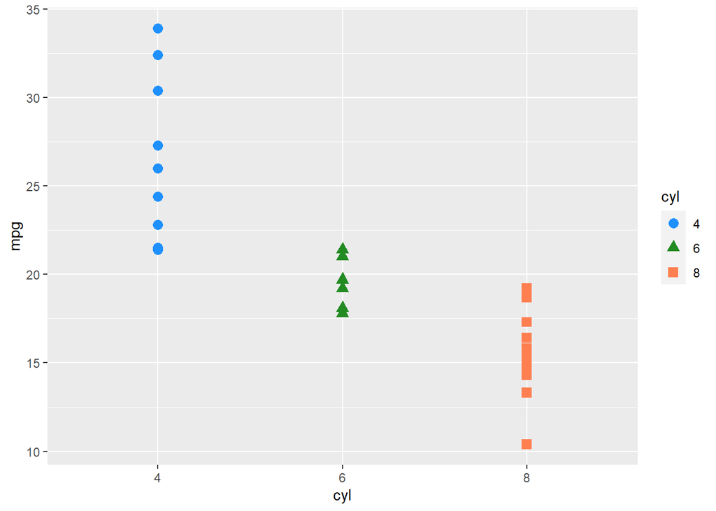

```r
mypalette<-c('dodgerblue', 'forestgreen', 'coral','grey','vermillion')

ggplot(data=mtcars, aes(x=cyl, y=mpg, shape=cyl))+
  geom_point(aes(color=cyl), size=3)+ #note that I changed point size to make it look nicer
  scale_color_manual(values=mypalette) #You still use scale_color_manual but you can pick the colors beforehand. Note that I picked a palette of 5 colors but only had 3 categories, so only the first 3 are used here.
```

### You can also brew your own color palette with the package “RColorBrewer.” I am not going to give examples of this, but feel free to mess around w/ this (google it)

### Finally, EASY and nice looking palettes with [ggsci](https://cran.r-project.org/web/packages/ggsci/vignettes/ggsci.html)

#### ggsci is a simple and neat package that allows us to use scientific journal color themes for our data (usually colorblind friendly and nice looking)

#### we simply change our “scale_color_manual” to “scale_color_palname” where “palname” is one of many provided by ggsci

#### for example, here is the Nature color palette and the AAAS color palette

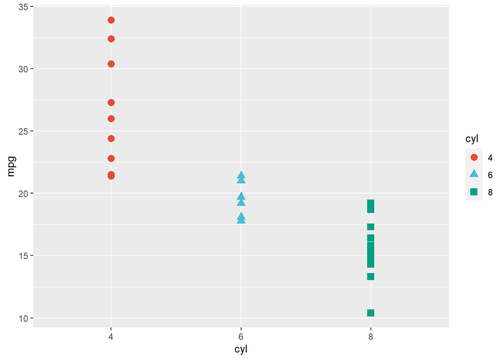

```r
ggplot(data=mtcars, aes(x=cyl, y=mpg, shape=cyl))+
  geom_point(aes(color=cyl), size=3)+
  scale_color_npg()
```

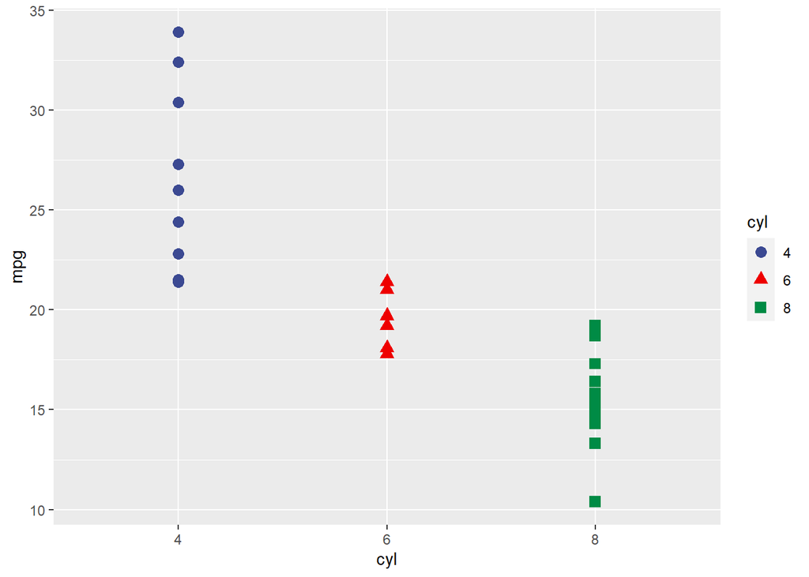

```r
ggplot(data=mtcars, aes(x=cyl, y=mpg, shape=cyl))+
  geom_point(aes(color=cyl), size=3)+
  scale_color_aaas()
```

## Advanced aesthetic options and building nice looking plots!

### [THEMES](https://ggplot2.tidyverse.org/reference/ggtheme.html)

#### ggplot provides many themes to make your plots look nice. My personal preference is to remove the gray background and most of the lines.

#### Here are “the best” (in my opinion) themes available in ggplot. I would recommend NOT using other ggplot themes unless you have very specific needs. These are the simplest and best looking.

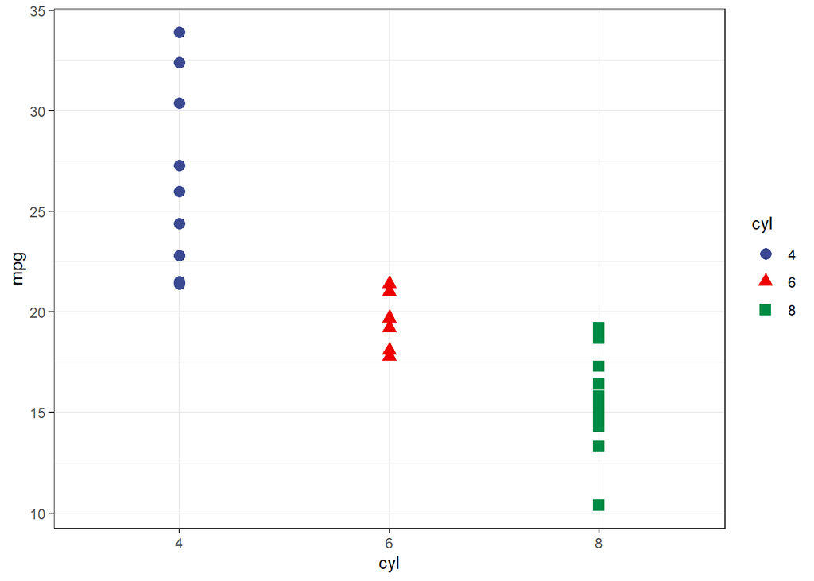

```r
ggplot(data=mtcars, aes(x=cyl, y=mpg, shape=cyl))+
  geom_point(aes(color=cyl), size=3)+
  scale_color_aaas()+
  theme_bw() #theme_bw removes the background color and adds a thick black border
```

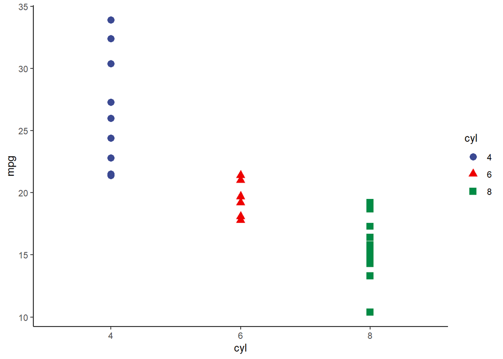

```r
ggplot(data=mtcars, aes(x=cyl, y=mpg, shape=cyl))+
  geom_point(aes(color=cyl), size=3)+
  scale_color_aaas()+
  theme_classic() #theme_classic removes the background color, all lines, and only keeps the X and Y axis (no border)
```

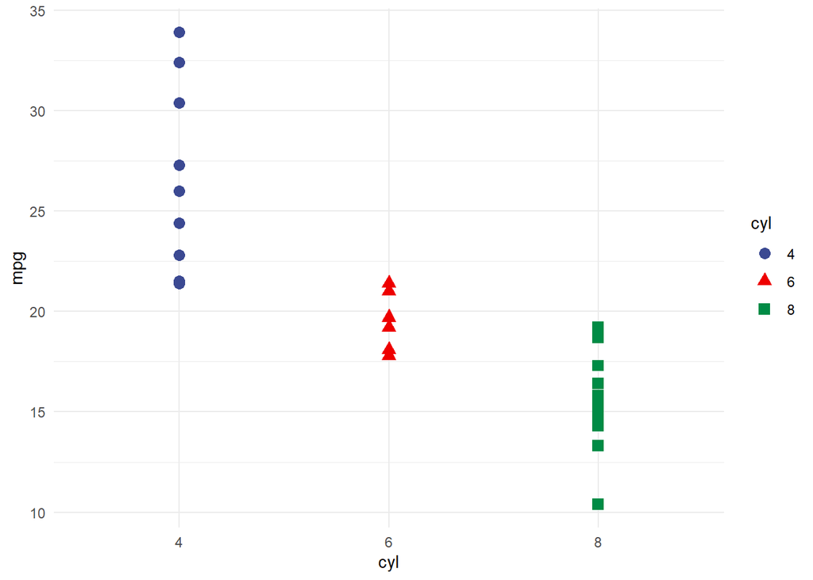

```r
ggplot(data=mtcars, aes(x=cyl, y=mpg, shape=cyl))+
  geom_point(aes(color=cyl), size=3)+
  scale_color_aaas()+
  theme_minimal() #theme_minimal removes the border and grey background
```

#### You can also make your own theme. ‘theme()’ allows you to change nearly any aspect of a ggplot (axes labels, tick marks, title, legends, etc)

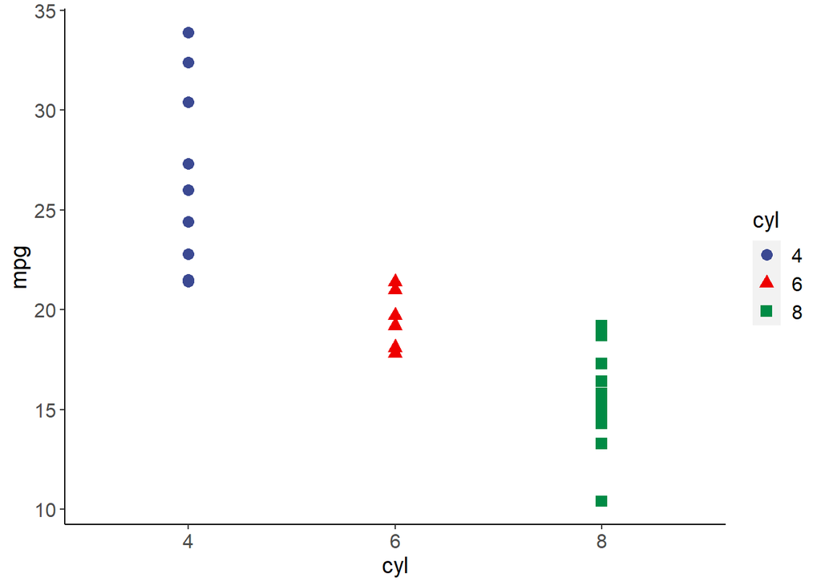

```r
  ggplot(data=mtcars, aes(x=cyl, y=mpg, shape=cyl))+
  geom_point(aes(color=cyl), size=3)+
  scale_color_aaas()+
  theme(panel.grid.major = element_blank(), panel.grid.minor = element_blank(),    ###this is essentially every kind of option you can change.
        panel.background = element_blank(), axis.line = element_line(colour = "black"),
        axis.text  = element_text(size=12),axis.title = element_text(size=14),
        legend.title = element_text(size=14), legend.text = element_text(size= 12))
```

### Change axes labels, titles, and legends

#### Making a title

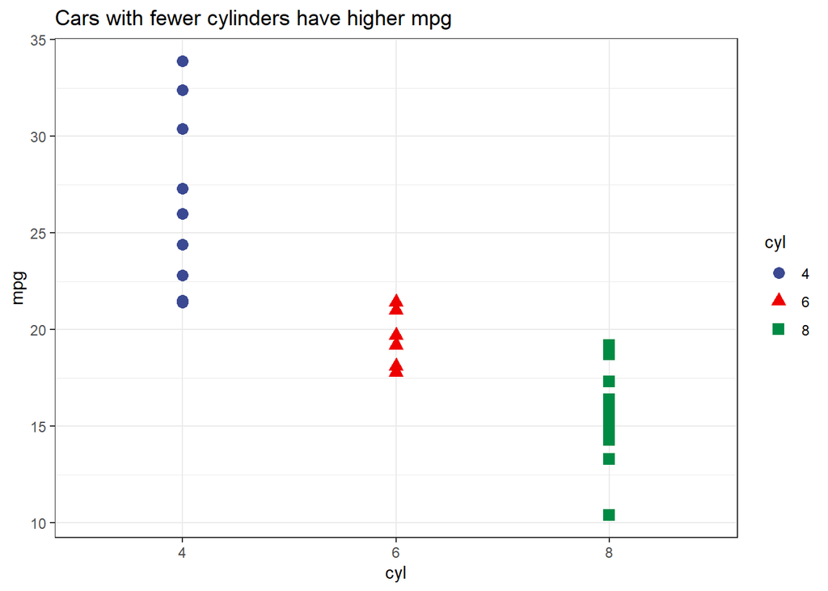

```r
 ggplot(data=mtcars, aes(x=cyl, y=mpg, shape=cyl))+
  geom_point(aes(color=cyl), size=3)+
  scale_color_aaas()+
  ggtitle("Cars with fewer cylinders have higher mpg")+
  theme_bw()
```

#### Labelling the axes

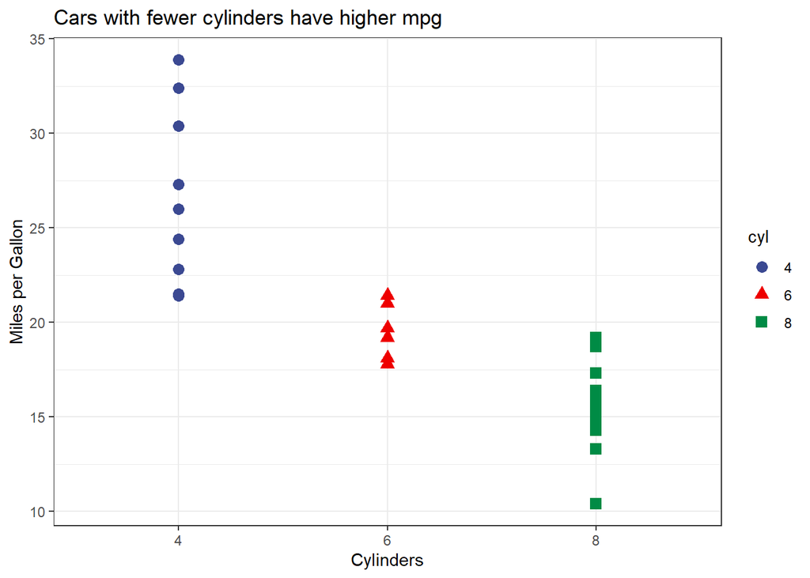

```r
 ggplot(data=mtcars, aes(x=cyl, y=mpg, shape=cyl))+
  geom_point(aes(color=cyl), size=3)+
  scale_color_aaas()+
  ggtitle("Cars with fewer cylinders have higher mpg")+
  theme_bw()+
  ylab('Miles per Gallon')+
  xlab('Cylinders')
```

#### Changing the label of the figure legend and legend elements

#### 1 option is to to use scale_shape_discrete (or color, or fill), give the legend a name and rename each item in the legend

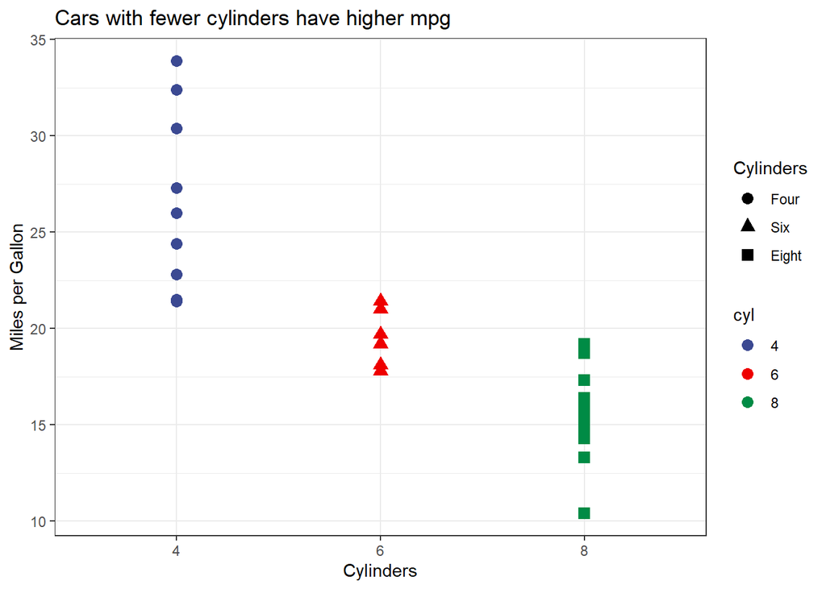

```r
 ggplot(data=mtcars, aes(x=cyl, y=mpg, shape=cyl))+
  geom_point(aes(color=cyl), size=3)+
  scale_color_aaas()+
  ggtitle("Cars with fewer cylinders have higher mpg")+
  theme_bw()+
  ylab('Miles per Gallon')+
  xlab('Cylinders')+
  scale_shape_discrete(name = 'Cylinders',
                      breaks=c('4','6','8'),
                      labels=c('Four','Six','Eight'))
```

#### Another is just a simple labs() function

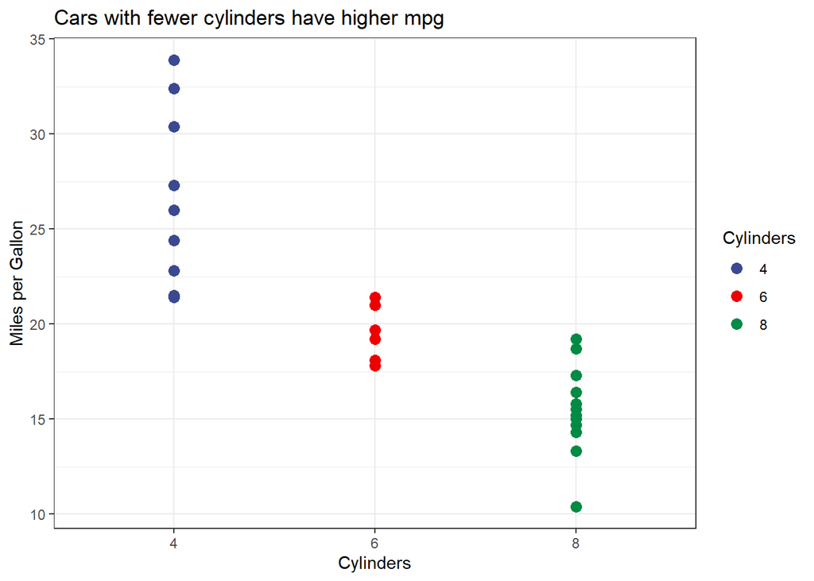

```r
 ggplot(data=mtcars, aes(x=cyl, y=mpg))+
  geom_point(aes(color=cyl), size=3)+
  scale_color_aaas()+
  ggtitle("Cars with fewer cylinders have higher mpg")+
  theme_bw()+
  ylab('Miles per Gallon')+
  xlab('Cylinders')+
  labs(color = "Cylinders") #note that I removed shape from the aes() so we didn't have 2 legends (because that is silly and looks bad)
```

### Change legend position

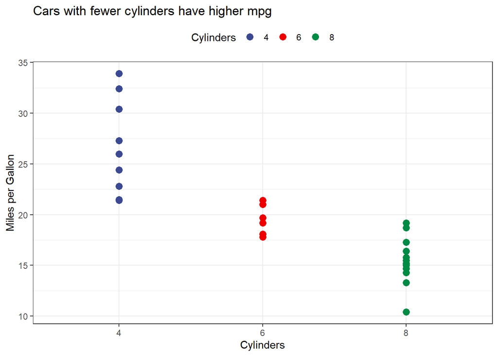

```r
 ggplot(data=mtcars, aes(x=cyl, y=mpg))+
  geom_point(aes(color=cyl), size=3)+
  scale_color_aaas()+
  ggtitle("Cars with fewer cylinders have higher mpg")+
  theme_bw()+
  ylab('Miles per Gallon')+
  xlab('Cylinders')+
  labs(color = "Cylinders")+
  theme(legend.position = "top")
```

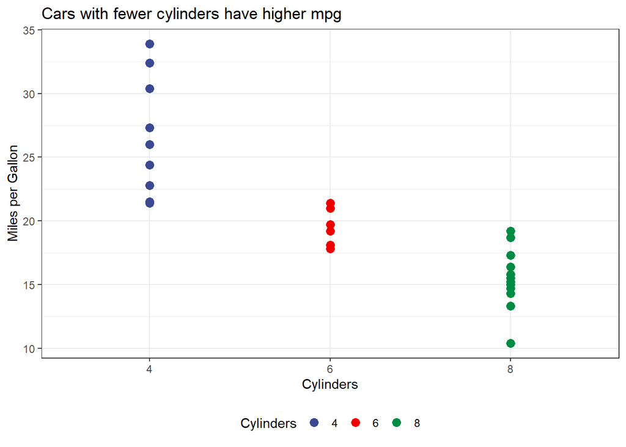

```r
 ggplot(data=mtcars, aes(x=cyl, y=mpg))+
  geom_point(aes(color=cyl), size=3)+
  scale_color_aaas()+
  ggtitle("Cars with fewer cylinders have higher mpg")+
  theme_bw()+
  ylab('Miles per Gallon')+
  xlab('Cylinders')+
  labs(color = "Cylinders")+
  theme(legend.position = "bottom")
```

## Facets- a new way to look at data

We can use facet_wrap or facet_grid to make multipanel plots!

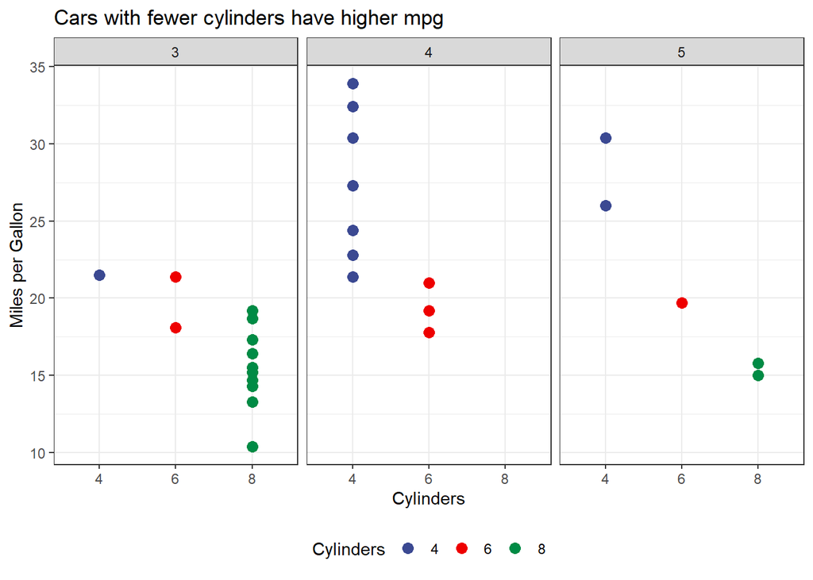

```r
mtcars$cyl=as.factor(mtcars$cyl)
mtcars$gear=as.factor(mtcars$gear)

 ggplot(data=mtcars, aes(x=cyl, y=mpg))+
  geom_point(aes(color=cyl), size=3)+
  scale_color_aaas()+
  facet_wrap(~gear)+
  ggtitle("Cars with fewer cylinders have higher mpg")+
  theme_bw()+
  ylab('Miles per Gallon')+
  xlab('Cylinders')+
  labs(color = "Cylinders")+
  theme(legend.position = "bottom")
```

## Multiple figures on the same page (and making it look cool)

#### Let’s look at the data we have been using in this example in several ways and pick the best looking option (by panelling them all on 1 page)!

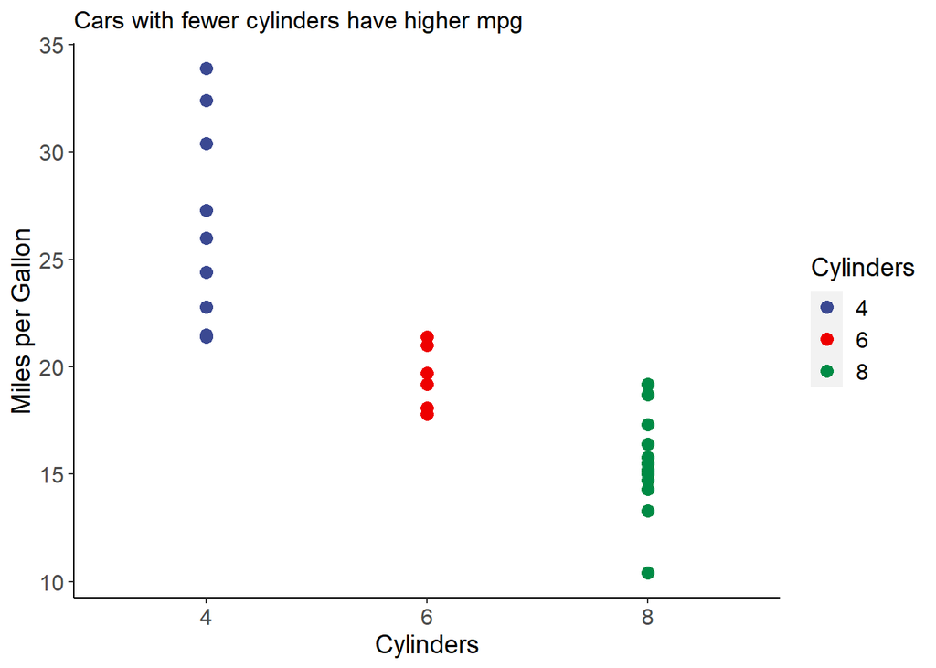

```r
opt1<- ggplot(data=mtcars, aes(x=cyl, y=mpg))+
  geom_point(aes(color=cyl), size=3)+
  scale_color_aaas()+
  ggtitle("Cars with fewer cylinders have higher mpg")+
  ylab('Miles per Gallon')+
  xlab('Cylinders')+
  labs(color = "Cylinders")+
  theme(panel.grid.major = element_blank(), panel.grid.minor = element_blank(),    ###this is essentially every kind of option you can change.
      panel.background = element_blank(), axis.line = element_line(colour = "black"),
      axis.text  = element_text(size=12),axis.title = element_text(size=14),
      legend.title = element_text(size=14), legend.text = element_text(size= 12))

opt1
```

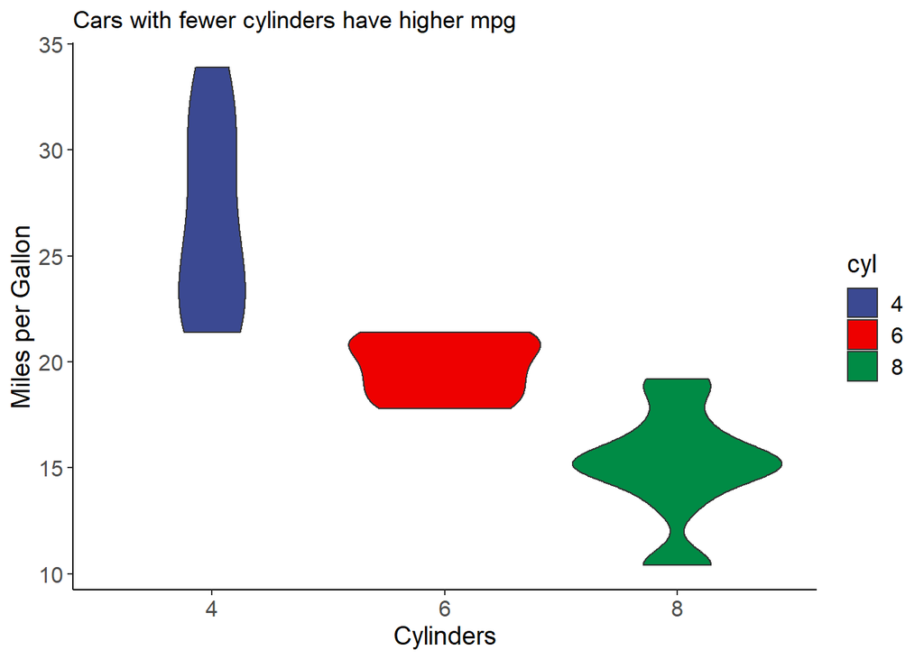

```r
opt2<- ggplot(data=mtcars, aes(x=cyl, y=mpg))+
  geom_violin(aes(fill=cyl))+
  scale_fill_aaas()+
  ggtitle("Cars with fewer cylinders have higher mpg")+
  ylab('Miles per Gallon')+
  xlab('Cylinders')+
  labs(color = "Cylinders")+
  theme(panel.grid.major = element_blank(), panel.grid.minor = element_blank(),    ###this is essentially every kind of option you can change.
      panel.background = element_blank(), axis.line = element_line(colour = "black"),
      axis.text  = element_text(size=12),axis.title = element_text(size=14),
      legend.title = element_text(size=14), legend.text = element_text(size= 12))

opt2
```

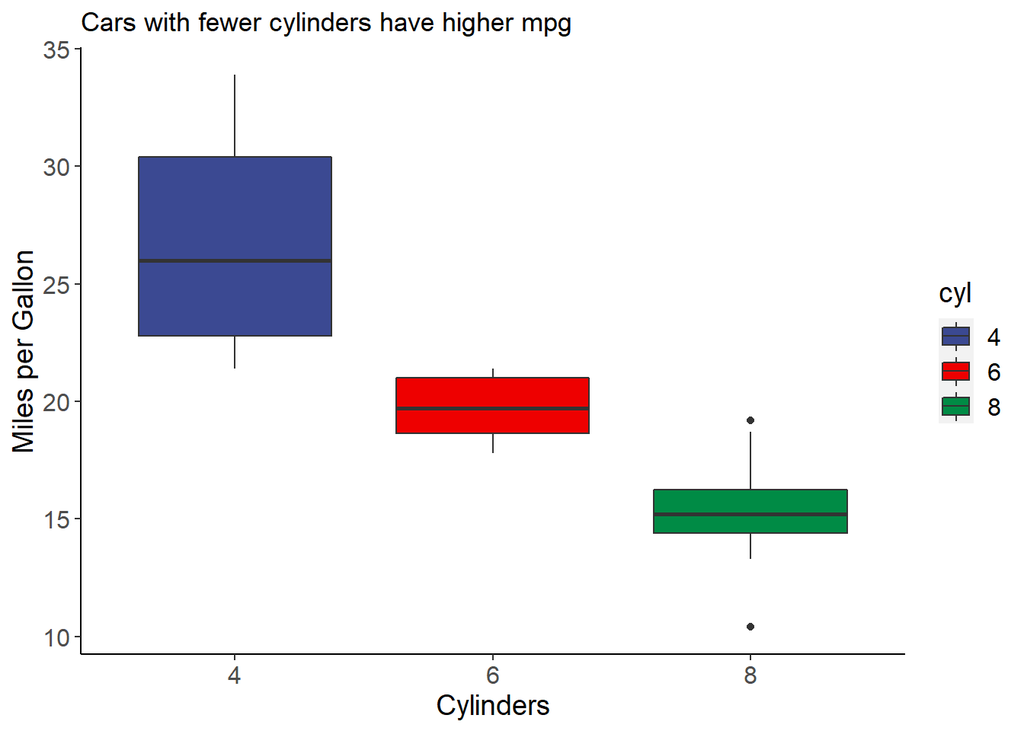

```r
opt3<- ggplot(data=mtcars, aes(x=cyl, y=mpg))+
  geom_boxplot(aes(fill=cyl))+
  scale_fill_aaas()+
  ggtitle("Cars with fewer cylinders have higher mpg")+
  ylab('Miles per Gallon')+
  xlab('Cylinders')+
  labs(color = "Cylinders")+
  theme(panel.grid.major = element_blank(), panel.grid.minor = element_blank(),    ###this is essentially every kind of option you can change.
      panel.background = element_blank(), axis.line = element_line(colour = "black"),
      axis.text  = element_text(size=12),axis.title = element_text(size=14),
      legend.title = element_text(size=14), legend.text = element_text(size= 12))

opt3
```

#### Now what if we take averages and plot means instead? What looks best / is most useful?

```r
#first we will calculate average MPG by cylinder (this is from last week)
mpgpercyl<-mtcars%>%
  group_by(cyl)%>%
  summarize(mean=mean(mpg),error=sd(mpg))
mpgpercyl
```

| cyl | mean | error |
| --- | --- | --- |
| 4 | 26.66364 | 4.509828 |
| 6 | 19.74286 | 1.453567 |
| 8 | 15.10000 | 2.560048 |

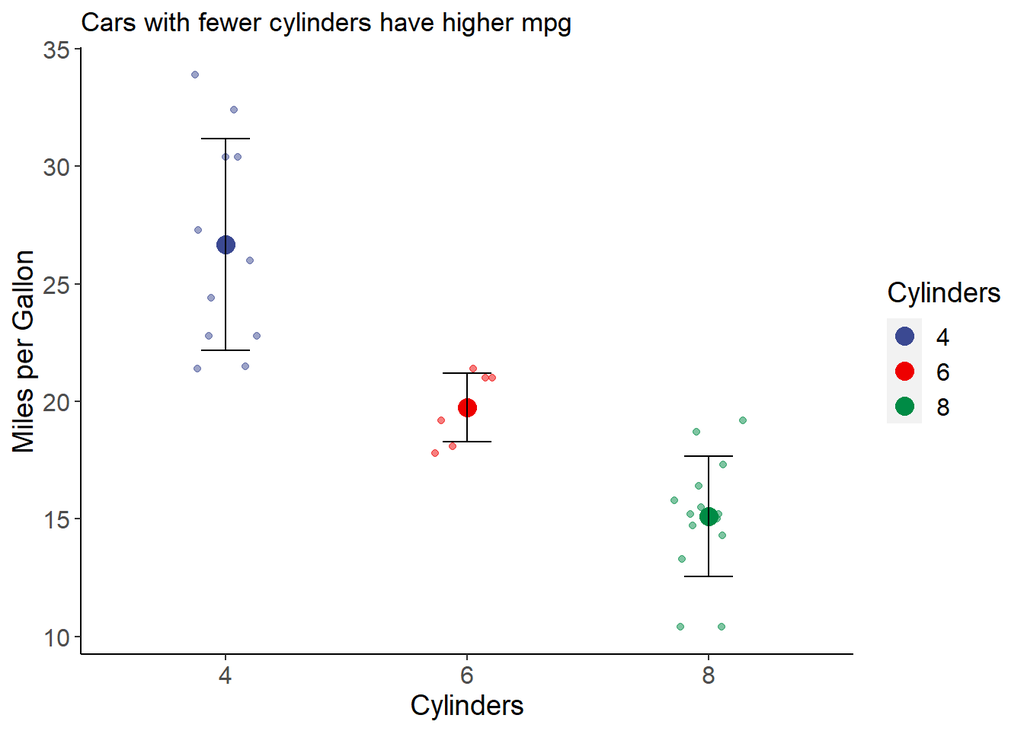

```r
opt4<- ggplot(data=mpgpercyl, aes(x=cyl, y=mean))+
  geom_jitter(data=mtcars, aes(x=cyl, y=mpg, color=cyl), alpha=0.5, width=0.15, height=0)+  #geom_jitter makes points randomly move around, we can control width and height, alpha = transparency
  geom_point(aes(color=cyl), size=4)+
  geom_errorbar(aes(x=cyl, ymax=mean+error, ymin=mean-error), width=0.2)+
  scale_fill_aaas()+
  scale_color_aaas()+
  ggtitle("Cars with fewer cylinders have higher mpg")+
  ylab('Miles per Gallon')+
  xlab('Cylinders')+
  labs(color = "Cylinders")+
  theme(panel.grid.major = element_blank(), panel.grid.minor = element_blank(),    ###this is essentially every kind of option you can change.
      panel.background = element_blank(), axis.line = element_line(colour = "black"),
      axis.text  = element_text(size=12),axis.title = element_text(size=14),
      legend.title = element_text(size=14), legend.text = element_text(size= 12))

opt4
```

### We have our 4 options, how can we panel them? Let’s use the ‘patchwork’ package! [patchwork](https://patchwork.data-imaginist.com/articles/patchwork.html)

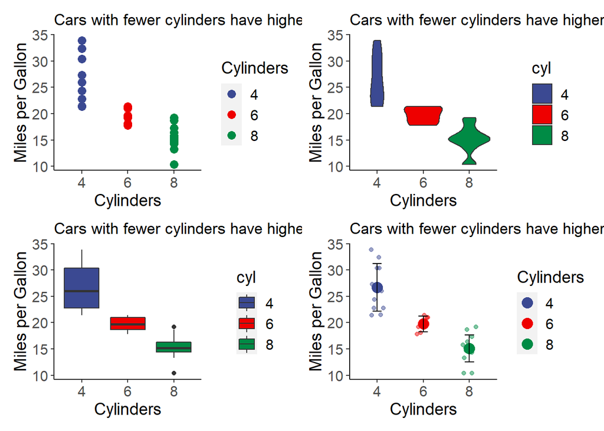

```r
# A sample patchwork, this actually works for our purposes...
opt1+opt2+opt3+opt4
```

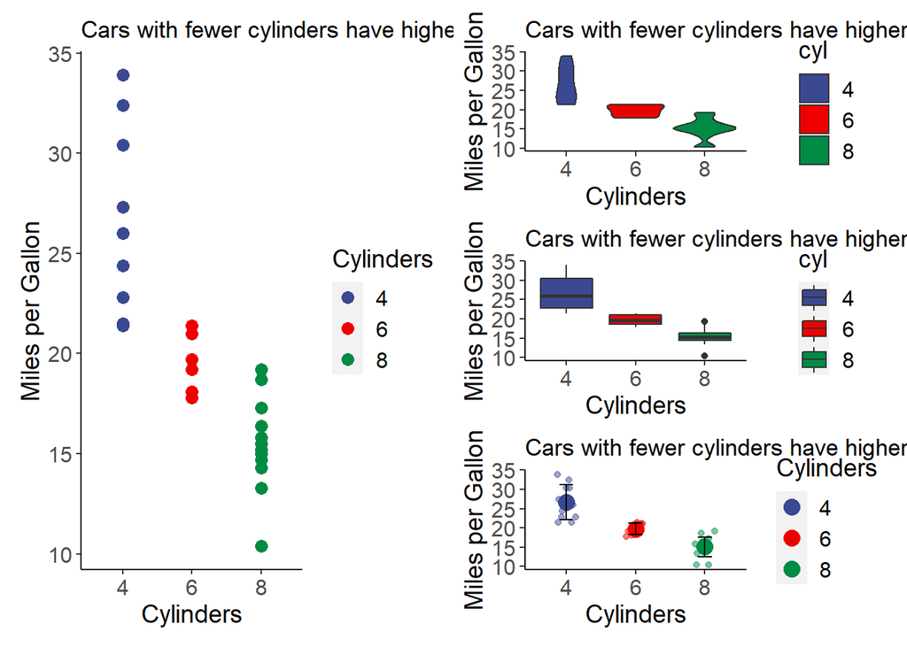

```r
#Other patchwork options
opt1+ (opt2/opt3/opt4)
```

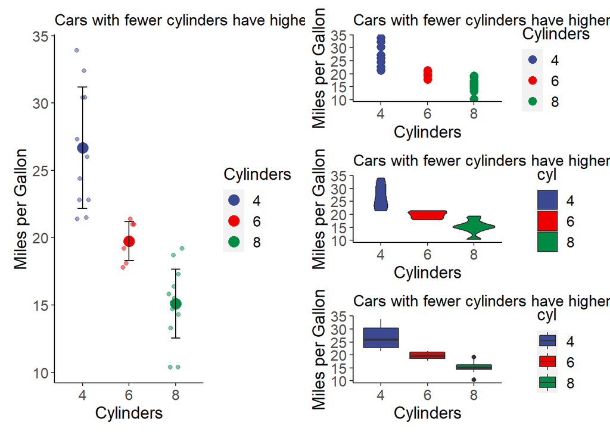

```r
#We can choose any plot to put on the left if we want :)
opt4 + (opt1/opt2/opt3)
```

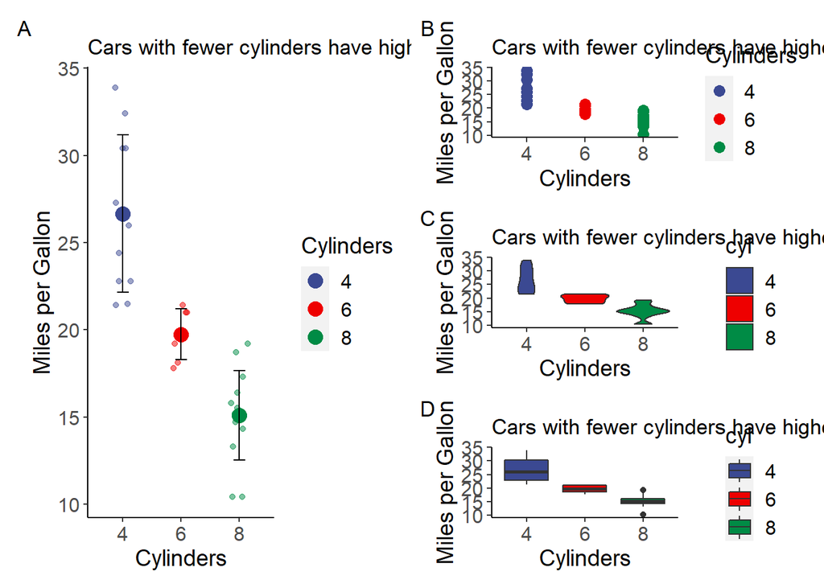

```r
#some more fancy options
opt4 + (opt1/opt2/opt3)+
  plot_annotation(tag_levels='A') #adds annotation (can use letters or roman numerals)
```

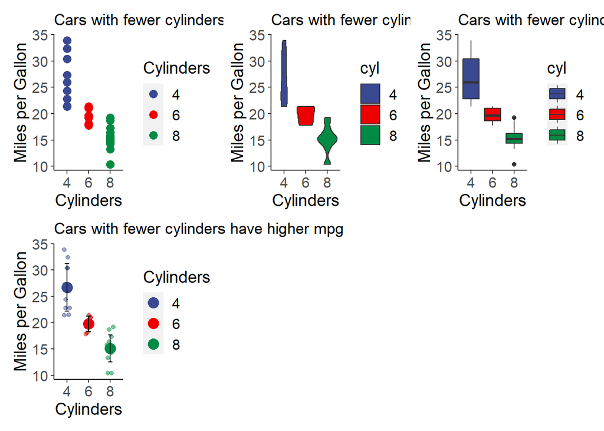

```r
opt1+opt2+opt3+opt4+plot_layout(ncol=3) #puts plots in 3 columns (any space not used will be blank)
```

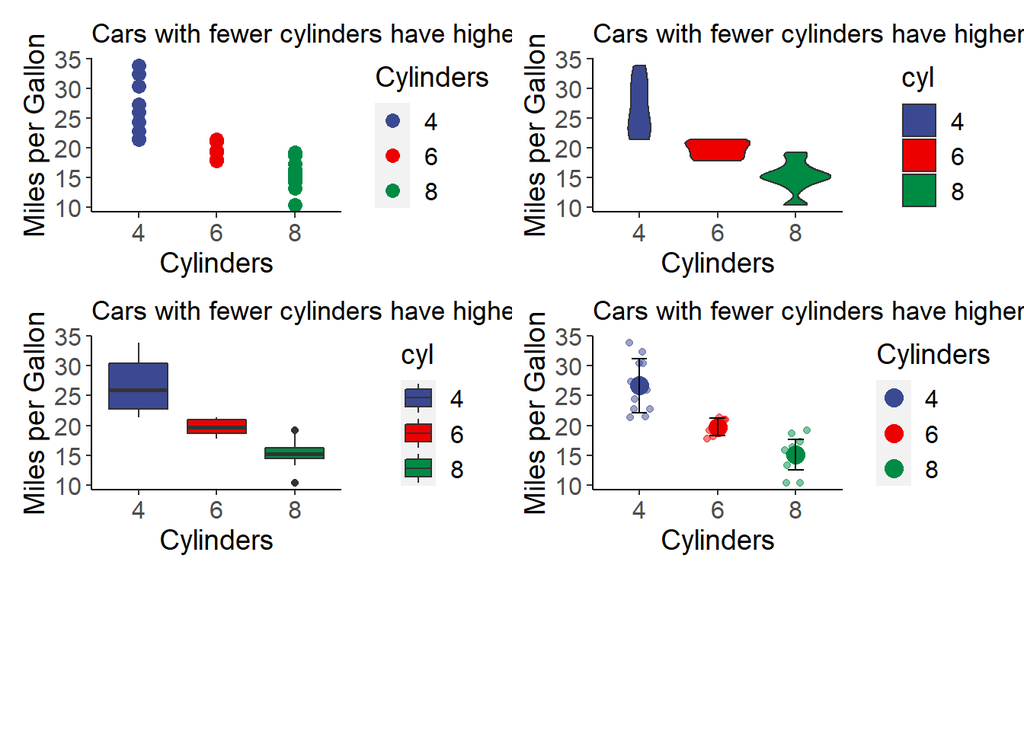

```r
opt1+opt2+opt3+opt4+plot_layout(nrow=3) #puts plots in 3 rows (any space not used will be blank)
```

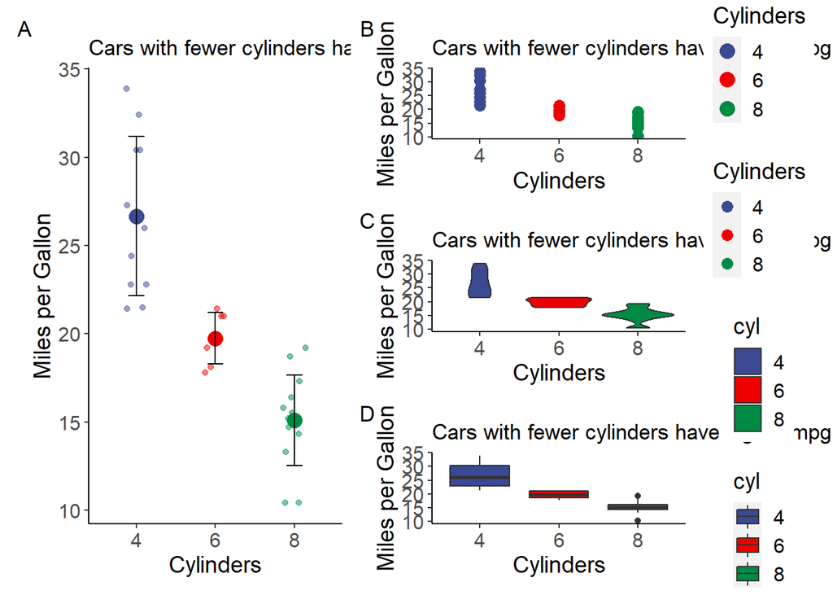

```r
opt4 + (opt1/opt2/opt3)+
  plot_annotation(tag_levels='A')+
  plot_layout(guides='collect') #collects all of the legends (in this case, puts them on the right...)
```

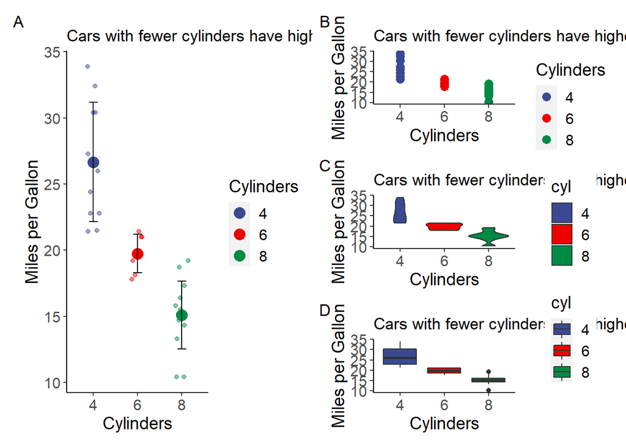

```r
(opt4+plot_layout(guides='auto')) + (opt1/opt2/opt3+plot_layout(guides='collect'))+
  plot_annotation(tag_levels='A')
```

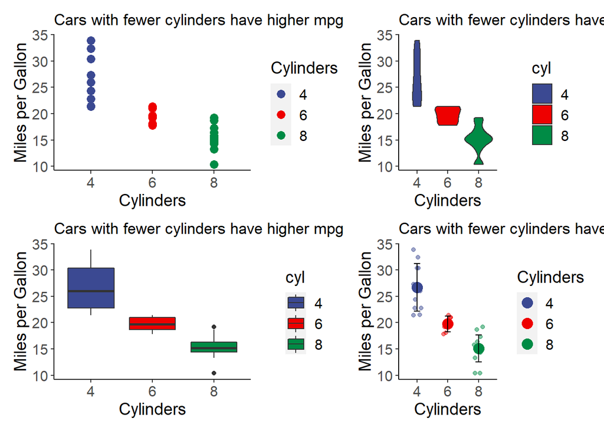

```r
opt1+opt2+opt3+opt4+
  plot_layout(widths=c(2,1)) #change width of columns
```

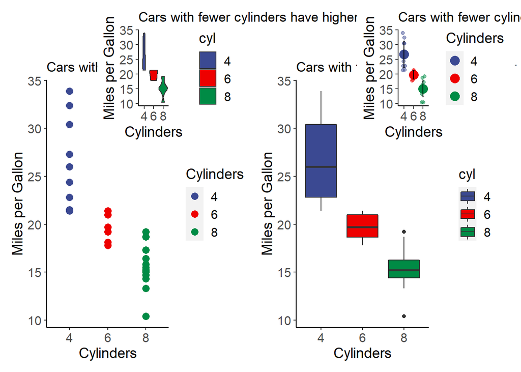

```r
#make a custom layout!
layout<- c(
  patchwork::area(t=2, l=1, b=9, r=8),
  patchwork::area(t = 1, l = 6, b = 2, r=8),
  patchwork::area(t= 2, l=9, b=9, r=17),
  patchwork::area(t = 1, l = 15, b = 2, r =17))

opt1+opt2+opt3+opt4+
  plot_layout(design=layout) #use our custom layout (this is a silly example, but you can see how it works)
```

### Which plot is best? I like this one:

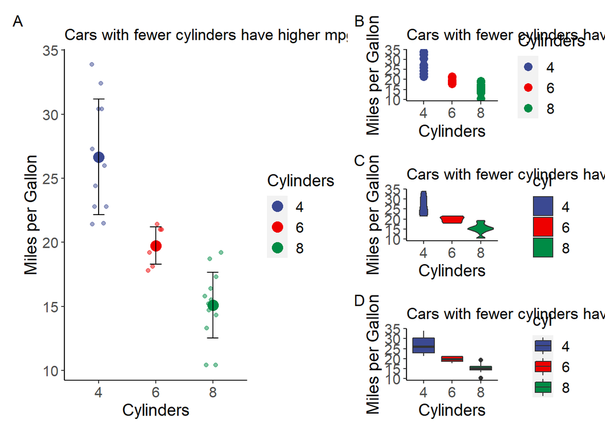

```r
opt4 + (opt1/opt2/opt3)+
  plot_annotation(tag_levels='A')+
  plot_layout(widths=c(2,1))
```

# **Step 3: Assignment for week 3**

## NOTE: use data other than mtcars for this! Please read in another dataset (perhaps from the tidytuesday data :) )

## 1.) Make a scatter plot, using conditional shape change

## 2.) Change the size of your points so that they fit the scale of your plot (not too small or too large)

## 3.) Remove the grey background from your figure and change the colors of your points (use ggsci if you want, but this is not required)

## 4.) Plot a mean + error range

## 5.) Build a bar chart or line graph instead of a scatterplot

## 6.) Try to make a patchwork plot that plots your scatterplot, average+error plot, and line/bar chart. Try to include a title that is informative for each plot and for the overall patchwork (see the patchwork website for help w/ this)

[output not shown]